# Typography

2018-09-29T11:36:33+08:00

> An apple is a sweet, edible fruit produced by an apple tree (Malus pumila). Apple trees are cultivated worldwide, and are the most widely grown species in the genus Malus. The tree originated in Central Asia, where its wild ancestor, Malus sieversii, is still found today. Apples have been grown for thousands of years in Asia and Europe, and were brought to North America by European colonists. Apples have religious and mythological significance in many cultures, including Norse, Greek and European Christian traditions.[^1]

Inline styles：

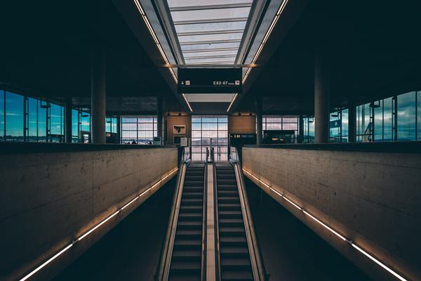

img

Headings:

# Heading 1

## Heading 2

### Heading 3

#### Heading 4

##### Heading 5

###### Heading 6

Table:

| Left-Aligned | Center Aligned | Right Aligned |
| --- | --- | --- |
| col 3 is | some wordy text | $1600 |
| col 2 is | centered | $12 |
| zebra stripes | are neat | $1 |

Lists:

- Unordered list item 1.
- Unordered list item 2.
1. ordered list item 1.
2. ordered list item 2.
   - sub-unordered list item 1.
   - sub-unordered list item 2.
     - something is DONE.
     - something is NOT DONE.

Syntax Highlighting:

```javascript
var num1, num2, sum
num1 = prompt("Enter first number")
num2 = prompt("Enter second number")
sum = parseInt(num1) + parseInt(num2) // "+" means "add"
alert("Sum = " + sum)  // "+" means combine into a string
```

[^1]: From https://en.wikipedia.org/wiki/Apple